# Shortened Removed: results03_population-probability-stats

Tommy Botch

2024-11-15

# Setup environment

## Load packages and setup paths for analysis

Set up directories - since we’re doing this locally (and mounting the server), we’re going to use a different base_dir

# Population-level analysis

## Data loading

Load data and set factors. Our columns are the following: - **modality:** which modality was the stimulus presented as (video, audio, text) - **ground_truth:** ground-truth word to be predicted - **top_pred:** most predicted word across the population - **word_index:** the word index within the story - **task:** which of the three stories was the data from (black, wheretheressmoke, howtodraw)

We create a contrast of modality such that we test the hypothesis that multimodal (video) > spoken (audio) > written (text).

```r
results_fn <- file.path(results_dir, "all-task_group-analyzed-behavior_human-lemmatized.csv")

# Load data and convert columns to factors
df_results <- load_and_prepare_data(
  file_path=results_fn,
  factor_columns=c('modality', 'ground_truth', 'top_pred', 'word_index','task',"POS_spaCy", "Clause_Pos", "Clause_ID")
)

# Set the levels for the modality column
df_results <- set_factor_levels(
  df=df_results,
  column_name="modality",
  levels=c("video", "audio", "text")
)

df_results <- create_column_contrast(
  df=df_results,
  column_name="modality",
)
```

## Analysis 1A - Predictability

We first investigate whether predictability (percentage of subjects predicting the correct word) varies based on the modality of the stimulus. We use a linear mixed-effects model with a log-link function, given that predictability is log distributed (e.g., floor is most common).

```r
predictability_formula <- 'predictability ~ modality + (1|word_index:task)'

# Fit the logistic mixed-effects model
model <- glmer(predictability_formula, data=df_results, family=gaussian(link='log'))

tab_model(model, show.se=TRUE, show.stat=TRUE, show.r2=TRUE, show.df=TRUE)
```

|  | predictability |  |  |  |  |  |
| --- | --- | --- | --- | --- | --- | --- |
| Predictors | Estimates | std. Error | CI | Statistic | p | df |
| (Intercept) | -2.63 | 0.07 | -2.77 – -2.49 | -37.10 | **<0.001** | 2011.00 |
| modality L | -0.26 | 0.01 | -0.28 – -0.24 | -25.66 | **<0.001** | 2011.00 |
| modality Q | -0.05 | 0.01 | -0.07 – -0.03 | -5.48 | **<0.001** | 2011.00 |
| Random Effects |  |  |  |  |  |  |
| σ<sup>2</sup> | 0.03 |  |  |  |  |  |
| τ<sub>00</sub> <sub>word_index:task</sub> | 0.92 |  |  |  |  |  |
| ICC | 0.97 |  |  |  |  |  |
| N <sub>word_index</sub> | 594 |  |  |  |  |  |
| N <sub>task</sub> | 3 |  |  |  |  |  |
| Observations | 2016 |  |  |  |  |  |
| Marginal R<sup>2</sup> / Conditional R<sup>2</sup> | 0.024 / 0.970 |  |  |  |  |  |

```r
# Conduct pairwise comparisons between modalities
pairwise_comparisons <- emmeans(model, pairwise ~ modality)
display_pairwise_comparisons(pairwise_comparisons)
```

Pairwise Comparisons

| Comparison Results Comparison | Comparison Results Difference in Mean | Comparison Results Standard Error | Comparison Results Degrees of Freedom | Comparison Results Z-Statistic | Comparison Results P-Value |
| --- | --- | --- | --- | --- | --- |
| video - audio | 0.1211150 | 0.01219728 | Inf | 9.929676 | 2.642331e-14 |
| video - text | 0.3690972 | 0.01438285 | Inf | 25.662319 | 0.000000e+00 |
| audio - text | 0.2479822 | 0.01492361 | Inf | 16.616762 | 0.000000e+00 |

## Analysis 1B - Predictability interaction with prosody

```r
predictability_formula <- 'predictability ~ modality * prominence_mean_words5 + (1|word_index:task)'

# Fit the mixed-effects model
model <- glmer(predictability_formula, data=df_results, family=gaussian(link='log'))

tab_model(model, show.se=TRUE, show.stat=TRUE, show.r2=TRUE, show.df=TRUE)
```

|  | predictability |  |  |  |  |  |
| --- | --- | --- | --- | --- | --- | --- |
| Predictors | Estimates | std. Error | CI | Statistic | p | df |
| (Intercept) | -2.66 | 0.11 | -2.88 – -2.45 | -24.04 | **<0.001** | 2008.00 |
| modality L | -0.23 | 0.02 | -0.27 – -0.20 | -11.95 | **<0.001** | 2008.00 |
| modality Q | -0.02 | 0.02 | -0.05 – 0.02 | -0.97 | 0.334 | 2008.00 |
| prominence mean words5 | 0.07 | 0.18 | -0.30 – 0.43 | 0.36 | 0.721 | 2008.00 |
| modality L × prominence mean words5 | -0.06 | 0.04 | -0.13 – 0.01 | -1.57 | 0.116 | 2008.00 |
| modality Q × prominence mean words5 | -0.07 | 0.03 | -0.13 – -0.01 | -2.21 | **0.027** | 2008.00 |
| Random Effects |  |  |  |  |  |  |
| σ<sup>2</sup> | 0.03 |  |  |  |  |  |
| τ<sub>00</sub> <sub>word_index:task</sub> | 0.92 |  |  |  |  |  |
| ICC | 0.97 |  |  |  |  |  |
| N <sub>word_index</sub> | 594 |  |  |  |  |  |
| N <sub>task</sub> | 3 |  |  |  |  |  |
| Observations | 2016 |  |  |  |  |  |
| Marginal R<sup>2</sup> / Conditional R<sup>2</sup> | 0.025 / 0.970 |  |  |  |  |  |

```r
# Conduct pairwise comparisons between modalities
pairwise_comparisons <- emmeans(model, pairwise ~ modality)
```

```
## NOTE: Results may be misleading due to involvement in interactions
```

```r
display_pairwise_comparisons(pairwise_comparisons)
```

Pairwise Comparisons

| Comparison Results Comparison | Comparison Results Difference in Mean | Comparison Results Standard Error | Comparison Results Degrees of Freedom | Comparison Results Z-Statistic | Comparison Results P-Value |
| --- | --- | --- | --- | --- | --- |
| video - audio | 0.1212133 | 0.01217675 | Inf | 9.95448 | 2.564615e-14 |
| video - text | 0.3695771 | 0.01436911 | Inf | 25.72025 | 0.000000e+00 |
| audio - text | 0.2483638 | 0.01490811 | Inf | 16.65965 | 0.000000e+00 |

### Plot the interaction between predictability and prosody

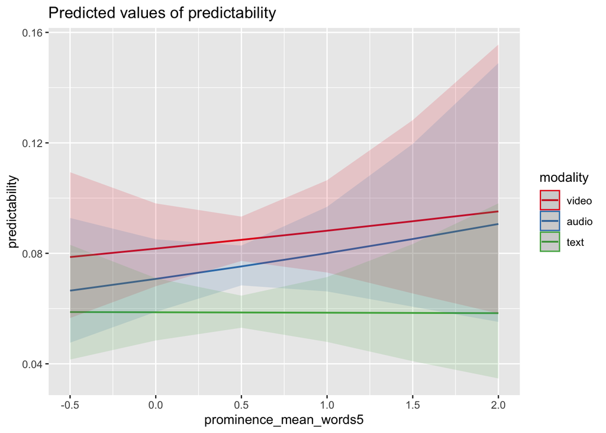

```r
plot_model(model, type='pred', terms=c('prominence_mean_words5', 'modality'))
```

## Analysis 1C - Task-level comparisons

```r
predictability_formula <- 'predictability ~ modality + (1|word_index)'
```

Now conduct the comparisons for each task.

### Story = Black

```r
model <- lmer_task(
  task_name='black',
  df=df_results,
  formula=predictability_formula,
  family=gaussian(link="log")
)

# Output the results
tab_model(model, show.se = TRUE, show.stat = TRUE, show.r2 = TRUE)
```

|  | Dependent variable |  |  |  |  |
| --- | --- | --- | --- | --- | --- |
| Predictors | Estimates | std. Error | CI | Statistic | p |
| (Intercept) | -2.44 | 0.14 | -2.70 – -2.17 | -18.05 | **<0.001** |
| modality L | -0.31 | 0.02 | -0.35 – -0.27 | -15.90 | **<0.001** |
| modality Q | -0.12 | 0.02 | -0.15 – -0.08 | -6.76 | **<0.001** |
| Random Effects |  |  |  |  |  |
| σ<sup>2</sup> | 0.03 |  |  |  |  |
| τ<sub>00</sub> <sub>word_index</sub> | 0.86 |  |  |  |  |
| ICC | 0.96 |  |  |  |  |
| N <sub>word_index</sub> | 194 |  |  |  |  |
| Observations | 582 |  |  |  |  |
| Marginal R<sup>2</sup> / Conditional R<sup>2</sup> | 0.039 / 0.965 |  |  |  |  |

```r
# Conduct pairwise comparisons between modalities
pairwise_comparisons <- emmeans(model, pairwise ~ modality)
display_pairwise_comparisons(pairwise_comparisons)
```

Pairwise Comparisons

| Comparison Results Comparison | Comparison Results Difference in Mean | Comparison Results Standard Error | Comparison Results Degrees of Freedom | Comparison Results Z-Statistic | Comparison Results P-Value |
| --- | --- | --- | --- | --- | --- |
| video - audio | 0.0771555 | 0.02168454 | Inf | 3.558089 | 0.001087891 |
| video - text | 0.4378497 | 0.02753519 | Inf | 15.901460 | 0.000000000 |
| audio - text | 0.3606942 | 0.02806269 | Inf | 12.853159 | 0.000000000 |

### Story = Smoke

```r
model <- lmer_task(
  task_name='wheretheressmoke',
  df=df_results,
  formula=predictability_formula,
  family=gaussian(link="log")
)

# Output the results
tab_model(model, show.se = TRUE, show.stat = TRUE, show.r2 = TRUE)
```

|  | Dependent variable |  |  |  |  |
| --- | --- | --- | --- | --- | --- |
| Predictors | Estimates | std. Error | CI | Statistic | p |
| (Intercept) | -2.56 | 0.12 | -2.80 – -2.33 | -21.44 | **<0.001** |
| modality L | -0.26 | 0.02 | -0.30 – -0.22 | -13.49 | **<0.001** |
| modality Q | 0.02 | 0.02 | -0.02 – 0.06 | 1.01 | 0.311 |
| Random Effects |  |  |  |  |  |
| σ<sup>2</sup> | 0.03 |  |  |  |  |
| τ<sub>00</sub> <sub>word_index</sub> | 0.85 |  |  |  |  |
| ICC | 0.96 |  |  |  |  |
| N <sub>word_index</sub> | 237 |  |  |  |  |
| Observations | 711 |  |  |  |  |
| Marginal R<sup>2</sup> / Conditional R<sup>2</sup> | 0.025 / 0.965 |  |  |  |  |

```r
# Conduct pairwise comparisons between modalities
pairwise_comparisons <- emmeans(model, pairwise ~ modality)
display_pairwise_comparisons(pairwise_comparisons)
```

Pairwise Comparisons

| Comparison Results Comparison | Comparison Results Difference in Mean | Comparison Results Standard Error | Comparison Results Degrees of Freedom | Comparison Results Z-Statistic | Comparison Results P-Value |
| --- | --- | --- | --- | --- | --- |
| video - audio | 0.2071502 | 0.02428150 | Inf | 8.531194 | 2.753353e-14 |
| video - text | 0.3674422 | 0.02723801 | Inf | 13.490052 | 0.000000e+00 |
| audio - text | 0.1602920 | 0.02911100 | Inf | 5.506235 | 1.098563e-07 |

### Story = Draw

```r
model <- lmer_task(
  task_name='howtodraw',
  df=df_results,
  formula=predictability_formula,
  family=gaussian(link="log")
)

# Output the results
tab_model(model, show.se = TRUE, show.stat = TRUE, show.r2 = TRUE)
```

|  | Dependent variable |  |  |  |  |
| --- | --- | --- | --- | --- | --- |
| Predictors | Estimates | std. Error | CI | Statistic | p |
| (Intercept) | -2.87 | 0.11 | -3.09 – -2.65 | -25.41 | **<0.001** |
| modality L | -0.22 | 0.01 | -0.24 – -0.19 | -16.01 | **<0.001** |
| modality Q | -0.06 | 0.01 | -0.08 – -0.03 | -4.33 | **<0.001** |
| Random Effects |  |  |  |  |  |
| σ<sup>2</sup> | 0.02 |  |  |  |  |
| τ<sub>00</sub> <sub>word_index</sub> | 1.03 |  |  |  |  |
| ICC | 0.98 |  |  |  |  |
| N <sub>word_index</sub> | 241 |  |  |  |  |
| Observations | 723 |  |  |  |  |
| Marginal R<sup>2</sup> / Conditional R<sup>2</sup> | 0.016 / 0.979 |  |  |  |  |

```r
# Conduct pairwise comparisons between modalities
pairwise_comparisons <- emmeans(model, pairwise ~ modality)
display_pairwise_comparisons(pairwise_comparisons)
```

Pairwise Comparisons

| Comparison Results Comparison | Comparison Results Difference in Mean | Comparison Results Standard Error | Comparison Results Degrees of Freedom | Comparison Results Z-Statistic | Comparison Results P-Value |
| --- | --- | --- | --- | --- | --- |
| video - audio | 0.08625062 | 0.01669158 | Inf | 5.167313 | 7.109459e-07 |
| video - text | 0.30752103 | 0.01920722 | Inf | 16.010696 | 0.000000e+00 |
| audio - text | 0.22127041 | 0.01978599 | Inf | 11.183189 | 7.993606e-15 |

## Analysis 2A - Entropy

We next look at whether entropy of human prediction distributions varies based on condition.

```r
entropy_formula <- 'entropy ~ modality + (1|word_index:task)'

# Fit the logistic mixed-effects model
model <- lmer(entropy_formula, data = df_results)

tab_model(model, show.se=TRUE, show.stat=TRUE, show.r2=TRUE, show.df=TRUE)
```

|  | entropy |  |  |  |  |  |
| --- | --- | --- | --- | --- | --- | --- |
| Predictors | Estimates | std. Error | CI | Statistic | p | df |
| (Intercept) | 2.04 | 0.03 | 1.99 – 2.10 | 67.90 | **<0.001** | 2011.00 |
| modality L | 0.18 | 0.01 | 0.15 – 0.21 | 12.07 | **<0.001** | 2011.00 |
| modality Q | -0.03 | 0.01 | -0.06 – -0.00 | -2.14 | **0.032** | 2011.00 |
| Random Effects |  |  |  |  |  |  |
| σ<sup>2</sup> | 0.15 |  |  |  |  |  |
| τ<sub>00</sub> <sub>word_index:task</sub> | 0.56 |  |  |  |  |  |
| ICC | 0.79 |  |  |  |  |  |
| N <sub>word_index</sub> | 594 |  |  |  |  |  |
| N <sub>task</sub> | 3 |  |  |  |  |  |
| Observations | 2016 |  |  |  |  |  |
| Marginal R<sup>2</sup> / Conditional R<sup>2</sup> | 0.015 / 0.793 |  |  |  |  |  |

```r
# Display results of fixed effects
display_model_summary(model)
```

Model Fixed Effects Summary

| Predictor | Fixed Effects Results Coefficient Estimate | Fixed Effects Results Standard Error | Fixed Effects Results T-Statistic | Fixed Effects Results P-Value | df |  |
| --- | --- | --- | --- | --- | --- | --- |
| (Intercept) | 2.04440540 | 0.03010993 | 67.898056 | 8.090034e-303 |  | 670.9999 |
| modality.L | 0.17998483 | 0.01490882 | 12.072372 | 6.243091e-32 | 1342.0000 |  |
| modality.Q | -0.03196154 | 0.01490882 | -2.143801 | 3.222813e-02 | 1342.0000 |  |

```r
# Conduct pairwise comparisons between modalities
pairwise_comparisons <- emmeans(model, pairwise ~ modality)
display_pairwise_comparisons(pairwise_comparisons)
```

Pairwise Comparisons

| Comparison Results Comparison | Comparison Results Difference in Mean | Comparison Results Standard Error | Comparison Results Degrees of Freedom | Comparison Results T-Statistic | Comparison Results P-Value |
| --- | --- | --- | --- | --- | --- |
| video - audio | -0.16641322 | 0.02108426 | 1342 | -7.892772 | 1.371125e-13 |
| video - text | -0.25453699 | 0.02108426 | 1342 | -12.072372 | 8.715251e-14 |
| audio - text | -0.08812376 | 0.02108426 | 1342 | -4.179600 | 9.213094e-05 |

## Analysis 2B - Entropy interaction with prosody

Include prosody (prominence_mean) within the model as an interaction effect.

```r
entropy_formula <- 'entropy ~ modality * prominence_mean_words5 + (1|word_index:task)'

# Fit the logistic mixed-effects model
model <- lmer(entropy_formula, data = df_results)

tab_model(model, show.se=TRUE, show.stat=TRUE, show.r2=TRUE, show.df=TRUE)
```

|  | entropy |  |  |  |  |  |
| --- | --- | --- | --- | --- | --- | --- |
| Predictors | Estimates | std. Error | CI | Statistic | p | df |
| (Intercept) | 2.05 | 0.06 | 1.93 – 2.16 | 34.83 | **<0.001** | 2008.00 |
| modality L | 0.14 | 0.03 | 0.08 – 0.20 | 4.85 | **<0.001** | 2008.00 |
| modality Q | -0.09 | 0.03 | -0.15 – -0.04 | -3.26 | **0.001** | 2008.00 |
| prominence mean words5 | -0.01 | 0.10 | -0.21 – 0.20 | -0.05 | 0.959 | 2008.00 |
| modality L × prominence mean words5 | 0.08 | 0.05 | -0.02 – 0.18 | 1.57 | 0.116 | 2008.00 |
| modality Q × prominence mean words5 | 0.13 | 0.05 | 0.03 – 0.23 | 2.52 | **0.012** | 2008.00 |
| Random Effects |  |  |  |  |  |  |
| σ<sup>2</sup> | 0.15 |  |  |  |  |  |
| τ<sub>00</sub> <sub>word_index:task</sub> | 0.56 |  |  |  |  |  |
| ICC | 0.79 |  |  |  |  |  |
| N <sub>word_index</sub> | 594 |  |  |  |  |  |
| N <sub>task</sub> | 3 |  |  |  |  |  |
| Observations | 2016 |  |  |  |  |  |
| Marginal R<sup>2</sup> / Conditional R<sup>2</sup> | 0.016 / 0.794 |  |  |  |  |  |

```r
# Display results of fixed effects
display_model_summary(model)
```

Model Fixed Effects Summary

| Predictor | Fixed Effects Results Coefficient Estimate | Fixed Effects Results Standard Error | Fixed Effects Results T-Statistic | Fixed Effects Results P-Value | df |  |
| --- | --- | --- | --- | --- | --- | --- |
| (Intercept) | 2.047003260 | 0.05876647 | 34.83284175 | 1.655054e-152 |  | 669.9999 |
| modality.L | 0.140782280 | 0.02900291 | 4.85407449 | 1.351431e-06 | 1340.0000 |  |
| modality.Q | -0.094602074 | 0.02900291 | -3.26181329 | 1.134884e-03 | 1340.0000 |  |
| prominence_mean_words5 | -0.005377652 | 0.10443995 | -0.05149037 | 9.589501e-01 | 669.9999 |  |
| modality.L:prominence_mean_words5 | 0.081150449 | 0.05154406 | 1.57439001 | 1.156334e-01 | 1340.0000 |  |
| modality.Q:prominence_mean_words5 | 0.129667776 | 0.05154406 | 2.51566878 | 1.199683e-02 | 1340.0000 |  |

```r
# Conduct pairwise comparisons between modalities
pairwise_comparisons <- emmeans(model, pairwise ~ modality)
```

```
## NOTE: Results may be misleading due to involvement in interactions
```

```r
display_pairwise_comparisons(pairwise_comparisons)
```

Pairwise Comparisons

| Comparison Results Comparison | Comparison Results Difference in Mean | Comparison Results Standard Error | Comparison Results Degrees of Freedom | Comparison Results T-Statistic | Comparison Results P-Value |
| --- | --- | --- | --- | --- | --- |
| video - audio | -0.16641322 | 0.02103098 | 1340 | -7.912764 | 0.000000e+00 |
| video - text | -0.25453699 | 0.02103098 | 1340 | -12.102951 | 0.000000e+00 |
| audio - text | -0.08812376 | 0.02103098 | 1340 | -4.190187 | 8.801441e-05 |

### Plot the interaction between prominence and entropy

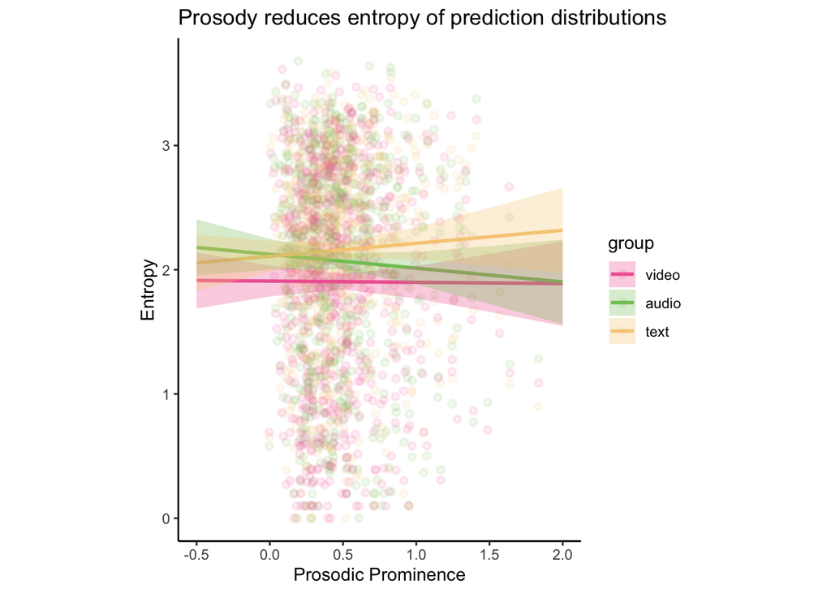

```r
preds <- data.frame(get_model_data(model, type='pred', terms = c("prominence_mean_words5", "modality")))

colors <- c('#F068A1', '#82C564', '#F7CD84')

ggplot(preds, aes(x=x, y=predicted, color=group)) +
  geom_point(
    data = df_results,
    aes(x=prominence_mean_words5, y=entropy, color=modality),
    stroke=1,
    alpha=0.1) +
  geom_line(size=1) +
  geom_ribbon(aes(ymin=conf.low, ymax=conf.high, fill=group), alpha=0.3, color=NA) +
  theme(
    aspect.ratio = 5/4,
    axis.line = element_line(colour = "black"),
    panel.grid.major = element_blank(),
    panel.grid.minor = element_blank(),
    panel.border = element_blank(),
    panel.background = element_blank()
  ) +
  scale_color_manual(values=colors) +
  scale_fill_manual(values=colors) +
  labs(
    x = "Prosodic Prominence",
    y = "Entropy",
    title = "Prosody reduces entropy of prediction distributions")
```

```r
# ggsave(file.path(plots_dir, 'human_entropy-prosody-interaction_new.pdf'), device = "pdf")
```

## Analysis 2C - Task-level comparisons

```r
entropy_formula <- 'entropy ~ modality + (1|word_index)'
```

Now conduct the comparisons for each task.

### Story = Black

```r
model <- lmer_task(
  task_name='black',
  df=df_results,
  formula=entropy_formula,
)

# Output the results
tab_model(model, show.se = TRUE, show.stat = TRUE, show.r2 = TRUE)
```

|  | Dependent variable |  |  |  |  |
| --- | --- | --- | --- | --- | --- |
| Predictors | Estimates | std. Error | CI | Statistic | p |
| (Intercept) | 1.99 | 0.06 | 1.88 – 2.11 | 34.00 | **<0.001** |
| modality L | 0.24 | 0.03 | 0.19 – 0.30 | 8.37 | **<0.001** |
| modality Q | 0.05 | 0.03 | -0.01 – 0.10 | 1.61 | 0.109 |
| Random Effects |  |  |  |  |  |
| σ<sup>2</sup> | 0.16 |  |  |  |  |
| τ<sub>00</sub> <sub>word_index</sub> | 0.61 |  |  |  |  |
| ICC | 0.79 |  |  |  |  |
| N <sub>word_index</sub> | 194 |  |  |  |  |
| Observations | 582 |  |  |  |  |
| Marginal R<sup>2</sup> / Conditional R<sup>2</sup> | 0.026 / 0.795 |  |  |  |  |

```r
# Display results of fixed effects
display_model_summary(model)
```

Model Fixed Effects Summary

| Predictor | Fixed Effects Results Coefficient Estimate | Fixed Effects Results Standard Error | Fixed Effects Results T-Statistic | Fixed Effects Results P-Value | df |  |
| --- | --- | --- | --- | --- | --- | --- |
| (Intercept) | 1.99125863 | 0.05856157 | 34.002820 | 1.976607e-83 |  | 193 |
| modality.L | 0.24261533 | 0.02899886 | 8.366375 | 1.099429e-15 | 386 |  |
| modality.Q | 0.04656698 | 0.02899886 | 1.605821 | 1.091309e-01 | 386 |  |

```r
# Conduct pairwise comparisons between modalities
pairwise_comparisons <- emmeans(model, pairwise ~ modality)
display_pairwise_comparisons(pairwise_comparisons)
```

Pairwise Comparisons

| Comparison Results Comparison | Comparison Results Difference in Mean | Comparison Results Standard Error | Comparison Results Degrees of Freedom | Comparison Results T-Statistic | Comparison Results P-Value |
| --- | --- | --- | --- | --- | --- |
| video - audio | -0.1145223 | 0.04101058 | 386 | -2.792506 | 1.513553e-02 |
| video - text | -0.3431099 | 0.04101058 | 386 | -8.366375 | 0.000000e+00 |
| audio - text | -0.2285876 | 0.04101058 | 386 | -5.573870 | 1.403394e-07 |

### Story = Smoke

```r
model <- lmer_task(
  task_name='wheretheressmoke',
  df=df_results,
  formula=entropy_formula,
)

# Output the results
tab_model(model, show.se = TRUE, show.stat = TRUE, show.r2 = TRUE)
```

|  | Dependent variable |  |  |  |  |
| --- | --- | --- | --- | --- | --- |
| Predictors | Estimates | std. Error | CI | Statistic | p |
| (Intercept) | 2.03 | 0.05 | 1.94 – 2.12 | 42.96 | **<0.001** |
| modality L | 0.12 | 0.03 | 0.07 – 0.17 | 4.54 | **<0.001** |
| modality Q | -0.11 | 0.03 | -0.16 – -0.06 | -4.16 | **<0.001** |
| Random Effects |  |  |  |  |  |
| σ<sup>2</sup> | 0.17 |  |  |  |  |
| τ<sub>00</sub> <sub>word_index</sub> | 0.47 |  |  |  |  |
| ICC | 0.74 |  |  |  |  |
| N <sub>word_index</sub> | 237 |  |  |  |  |
| Observations | 711 |  |  |  |  |
| Marginal R<sup>2</sup> / Conditional R<sup>2</sup> | 0.014 / 0.743 |  |  |  |  |

```r
# Display results of fixed effects
display_model_summary(model)
```

Model Fixed Effects Summary

| Predictor | Fixed Effects Results Coefficient Estimate | Fixed Effects Results Standard Error | Fixed Effects Results T-Statistic | Fixed Effects Results P-Value | df |  |
| --- | --- | --- | --- | --- | --- | --- |
| (Intercept) | 2.0280833 | 0.04720615 | 42.962267 | 1.478448e-113 |  | 236 |
| modality.L | 0.1203302 | 0.02650103 | 4.540587 | 7.129896e-06 | 472 |  |
| modality.Q | -0.1101568 | 0.02650103 | -4.156699 | 3.834690e-05 | 472 |  |

```r
# Conduct pairwise comparisons between modalities
pairwise_comparisons <- emmeans(model, pairwise ~ modality)
display_pairwise_comparisons(pairwise_comparisons)
```

Pairwise Comparisons

| Comparison Results Comparison | Comparison Results Difference in Mean | Comparison Results Standard Error | Comparison Results Degrees of Freedom | Comparison Results T-Statistic | Comparison Results P-Value |
| --- | --- | --- | --- | --- | --- |
| video - audio | -0.22000030 | 0.03747811 | 472 | -5.870101 | 2.465462e-08 |
| video - text | -0.17017263 | 0.03747811 | 472 | -4.540587 | 2.122154e-05 |
| audio - text | 0.04982767 | 0.03747811 | 472 | 1.329514 | 3.794695e-01 |

### Story = Draw

```r
model <- lmer_task(
  task_name='howtodraw',
  df=df_results,
  formula=entropy_formula,
)

# Output the results
tab_model(model, show.se = TRUE, show.stat = TRUE, show.r2 = TRUE)
```

|  | Dependent variable |  |  |  |  |
| --- | --- | --- | --- | --- | --- |
| Predictors | Estimates | std. Error | CI | Statistic | p |
| (Intercept) | 2.10 | 0.05 | 2.00 – 2.20 | 40.72 | **<0.001** |
| modality L | 0.19 | 0.02 | 0.15 – 0.23 | 8.66 | **<0.001** |
| modality Q | -0.02 | 0.02 | -0.06 – 0.02 | -0.84 | 0.400 |
| Random Effects |  |  |  |  |  |
| σ<sup>2</sup> | 0.11 |  |  |  |  |
| τ<sub>00</sub> <sub>word_index</sub> | 0.61 |  |  |  |  |
| ICC | 0.84 |  |  |  |  |
| N <sub>word_index</sub> | 241 |  |  |  |  |
| Observations | 723 |  |  |  |  |
| Marginal R<sup>2</sup> / Conditional R<sup>2</sup> | 0.016 / 0.844 |  |  |  |  |

```r
# Display results of fixed effects
display_model_summary(model)
```

Model Fixed Effects Summary

| Predictor | Fixed Effects Results Coefficient Estimate | Fixed Effects Results Standard Error | Fixed Effects Results T-Statistic | Fixed Effects Results P-Value | df |  |
| --- | --- | --- | --- | --- | --- | --- |
| (Intercept) | 2.10323859 | 0.05165135 | 40.7199142 | 9.273046e-110 |  | 240 |
| modality.L | 0.18823307 | 0.02172629 | 8.6638384 | 7.012788e-17 | 480 |  |
| modality.Q | -0.01827795 | 0.02172629 | -0.8412824 | 4.006086e-01 | 480 |  |

```r
# Conduct pairwise comparisons between modalities
pairwise_comparisons <- emmeans(model, pairwise ~ modality)
display_pairwise_comparisons(pairwise_comparisons)
```

Pairwise Comparisons

| Comparison Results Comparison | Comparison Results Difference in Mean | Comparison Results Standard Error | Comparison Results Degrees of Freedom | Comparison Results T-Statistic | Comparison Results P-Value |
| --- | --- | --- | --- | --- | --- |
| video - audio | -0.1554867 | 0.03072561 | 480 | -5.060491 | 1.783945e-06 |
| video - text | -0.2662018 | 0.03072561 | 480 | -8.663838 | 5.165290e-11 |
| audio - text | -0.1107151 | 0.03072561 | 480 | -3.603347 | 1.009692e-03 |

## Supplementary Analysis - Leakage filtering

```r
df_results_filtered <- subset(df_results, !df_results$filter_for_leakage)
```

### Supplementary Analysis 1A - Predictability

```r
predictability_formula <- 'predictability ~ modality + (1|word_index:task)'

# Fit the mixed-effects model
model <- glmer(predictability_formula, data=df_results_filtered, family=gaussian(link='log'))

tab_model(model, show.se=TRUE, show.stat=TRUE, show.r2=TRUE, show.df=TRUE)
```

|  | predictability |  |  |  |  |  |
| --- | --- | --- | --- | --- | --- | --- |
| Predictors | Estimates | std. Error | CI | Statistic | p | df |
| (Intercept) | -2.61 | 0.07 | -2.75 – -2.46 | -34.77 | **<0.001** | 1798.00 |
| modality L | -0.24 | 0.01 | -0.26 – -0.22 | -23.68 | **<0.001** | 1798.00 |
| modality Q | -0.04 | 0.01 | -0.06 – -0.03 | -4.62 | **<0.001** | 1798.00 |
| Random Effects |  |  |  |  |  |  |
| σ<sup>2</sup> | 0.03 |  |  |  |  |  |
| τ<sub>00</sub> <sub>word_index:task</sub> | 0.93 |  |  |  |  |  |
| ICC | 0.97 |  |  |  |  |  |
| N <sub>word_index</sub> | 537 |  |  |  |  |  |
| N <sub>task</sub> | 3 |  |  |  |  |  |
| Observations | 1803 |  |  |  |  |  |
| Marginal R<sup>2</sup> / Conditional R<sup>2</sup> | 0.021 / 0.969 |  |  |  |  |  |

```r
# Conduct pairwise comparisons between modalities
pairwise_comparisons <- emmeans(model, pairwise ~ modality)
display_pairwise_comparisons(pairwise_comparisons)
```

Pairwise Comparisons

| Comparison Results Comparison | Comparison Results Difference in Mean | Comparison Results Standard Error | Comparison Results Degrees of Freedom | Comparison Results Z-Statistic | Comparison Results P-Value |
| --- | --- | --- | --- | --- | --- |
| video - audio | 0.1170084 | 0.01247795 | Inf | 9.377212 | 2.842171e-14 |
| video - text | 0.3427363 | 0.01447657 | Inf | 23.675246 | 0.000000e+00 |
| audio - text | 0.2257279 | 0.01503256 | Inf | 15.015927 | 0.000000e+00 |

### Supplementary Analysis 2A - Entropy

```r
entropy_formula <- 'entropy ~ modality + (1|word_index:task)'

# Fit the logistic mixed-effects model
model <- lmer(entropy_formula, data = df_results_filtered)

tab_model(model, show.se=TRUE, show.stat=TRUE, show.r2=TRUE, show.df=TRUE)
```

|  | entropy |  |  |  |  |  |
| --- | --- | --- | --- | --- | --- | --- |
| Predictors | Estimates | std. Error | CI | Statistic | p | df |
| (Intercept) | 2.01 | 0.03 | 1.95 – 2.07 | 61.87 | **<0.001** | 1798.00 |
| modality L | 0.17 | 0.02 | 0.14 – 0.20 | 11.30 | **<0.001** | 1798.00 |
| modality Q | -0.03 | 0.02 | -0.06 – -0.00 | -2.04 | **0.042** | 1798.00 |
| Random Effects |  |  |  |  |  |  |
| σ<sup>2</sup> | 0.14 |  |  |  |  |  |
| τ<sub>00</sub> <sub>word_index:task</sub> | 0.59 |  |  |  |  |  |
| ICC | 0.81 |  |  |  |  |  |
| N <sub>word_index</sub> | 537 |  |  |  |  |  |
| N <sub>task</sub> | 3 |  |  |  |  |  |
| Observations | 1803 |  |  |  |  |  |
| Marginal R<sup>2</sup> / Conditional R<sup>2</sup> | 0.014 / 0.808 |  |  |  |  |  |

```r
# Display results of fixed effects
display_model_summary(model)
```

Model Fixed Effects Summary

| Predictor | Fixed Effects Results Coefficient Estimate | Fixed Effects Results Standard Error | Fixed Effects Results T-Statistic | Fixed Effects Results P-Value | df |  |
| --- | --- | --- | --- | --- | --- | --- |
| (Intercept) | 2.01097449 | 0.03250262 | 61.871151 | 1.337020e-262 |  | 599.9999 |
| modality.L | 0.17386859 | 0.01538670 | 11.299924 | 3.299709e-28 | 1200.0000 |  |
| modality.Q | -0.03137048 | 0.01538670 | -2.038804 | 4.168836e-02 | 1200.0000 |  |

```r
# Conduct pairwise comparisons between modalities
pairwise_comparisons <- emmeans(model, pairwise ~ modality)
display_pairwise_comparisons(pairwise_comparisons)
```

Pairwise Comparisons

| Comparison Results Comparison | Comparison Results Difference in Mean | Comparison Results Standard Error | Comparison Results Degrees of Freedom | Comparison Results T-Statistic | Comparison Results P-Value |
| --- | --- | --- | --- | --- | --- |
| video - audio | -0.16136449 | 0.02176009 | 1200 | -7.415618 | 8.707479e-13 |
| video - text | -0.24588732 | 0.02176009 | 1200 | -11.299924 | 1.727507e-13 |
| audio - text | -0.08452282 | 0.02176009 | 1200 | -3.884306 | 3.184556e-04 |